# quarto-input91f45d8e

第７回 ばらつきを測ってみよう！

**この講義の目標**

**1. 分散と標準偏差の計算と意味について学ぶ**  
**2. 変動係数の計算と意味について学ぶ**  
**3. 標準化と偏差値の計算と意味について学ぶ**

**[推奨]**  
※今回の`Python`コードも，[こちら](https://colab.research.google.com/drive/1iuo4NDD3VA9OERs67814vwCRqMkMRDnU?usp=sharing)のリンクからアクセスできます．

自分でコードを動かしたい人はぜひやってみましょう．

## 1. 分散と標準偏差

今回のテーマは**ばらつき**です．第３回目の授業で統計学的考え方について学びました．そのとき**統計学者はデータのばらつき（偏差）をとても重要視している**ということを学んだと思います．今日はそのばらつきを数値化したり，それを使ってデータを解釈する方法を学びましょう．

個々のデータのばらつき具合は，各データと平均値の差$x_i - \bar{x}$である**偏差（deviation）**でみることができますが，変数全体のばらつきについては**分散（variance）と標準偏差（standard deviation）**という統計量を使います．

分散と標準偏差の定義は以下の通りです．

**分散（variance）/ 標準偏差（standard deviation）**

ある量的変数$X$の$n$個の観測値が$x_1, x_2, \cdots x_n$と得られているとする．

このとき**分散（variance）**$s^2$を以下の数式で定義する．

$$s^2 = \frac{1}{n}\{(x_1-\bar{x})^2 + (x_2-\bar{x})^2 + \cdots + (x_n-\bar{x})^2\} = \frac{1}{n}\sum_{i=1}^{n} (x_i - \bar{x})^2$$

また，その正の平方根を**標準偏差（standard deviation）**$s$として，

$$s = \sqrt{s^2} = \sqrt{\frac{1}{n}\sum_{i=1}^{n} (x_i - \bar{x})^2}$$
と定義する．

ちなみに両式に共通してある，

$$\sum_{i=1}^{n}(x_i - \bar{x})^2$$
の部分を**偏差平方和（Sum of Squared Deviation：SSD）**といいます．こちらもよく出てくる言葉なので知っておくといいですね．

整理された数式だけみていてもよくわからないかもしれないので，**分散と標準偏差のイメージ**を黒板を使って説明しましょう（授業動画を見てください）．

## 2. 分散の計算

さて，分散と標準偏差について理解が深まってきたでしょうか？さらに理解を深めるために，具体的な例で計算をしてみることにします．

**問題１**

以下のような，２つのクラスA,Bの数学の期末試験の得点データを考える．

| 番号 | クラスA | クラスB |
| --- | --- | --- |
| 1 | 80 | 100 |
| 2 | 70 | 30 |
| 3 | 60 | 70 |
| 4 | 75 | 90 |
| 5 | 65 | 60 |

クラスA, クラスB，それぞれの分散，標準偏差を手計算（電卓は使っていい）しなさい．

**解答１**

以下のような表を作成してみると良い．

| 番号 | クラスA | クラスB | A偏差 | B偏差 | A偏差平方 | B偏差平方 |
| --- | --- | --- | --- | --- | --- | --- |
| 1 | 80 | 100 | 10 | 30 | 100 | 900 |
| 2 | 70 | 30 | 0 | -40 | 0 | 1600 |
| 3 | 60 | 70 | -10 | 0 | 100 | 0 |
| 4 | 75 | 90 | 5 | 20 | 25 | 400 |
| 5 | 65 | 60 | -5 | -10 | 25 | 100 |
| 平均 | 70 | 70 |  |  |  |  |
| 総和 |  |  | 0 | 0 | 250 | 3000 |

上の表からクラスA，Bの分散$s^2_A, s^2_B$は

$$s^2_A = \frac{250}{5} = 50$$
$$s^2_B = \frac{3000}{5} = 600$$
となり，標準偏差$s_A, s_B$は

$$s_A = \sqrt{50} \approx 7.07$$
$$s_B = \sqrt{600} \approx 24.5$$
となる． `Python`で計算するなら，例えば以下のようにする．

```python
import numpy as np

#データの作成
A = [80, 70, 60, 75, 65]
B = [100, 30, 70, 90, 60]

#分散の計算
np.var(A)
```

```
50.0
```

```python
np.var(B)
```

```
600.0
```

```python
#標準偏差の計算
np.std(A)
```

```
7.0710678118654755
```

```python
np.std(B)
```

```
24.49489742783178
```

## 3. （発展）不偏分散

先ほど，教科書中で分散の式を定義しました．しかし，あなたが統計学をより深く学んでいくと，以下のような分散の定義式を見かけることでしょう．

**不偏分散（unbiased variance）**

ある量的変数$X$の$n$個の観測値が$x_1, x_2, \cdots x_n$と得られているとする．

このとき**不偏分散（unbiased variance）**$s_u^2$を以下の数式で定義する．
$$s_{u}^{2} = \frac{1}{n-1} \sum_{i=1}^{n}(x_i - \bar{x})^2$$

先ほどの式と似てはいますが，少し違う部分がありますね．先ほどは偏差平方和を$\frac{1}{n}$**で割っていた**のに対して，今回の式は$\frac{1}{n-1}$**で割られています．**この値は**不偏分散（unbiased variance）**と呼ばれる値で，実は統計学ではこちらの式の方が使われることが多いのです．

ちなみに`Python`で計算するなら以下のようにします．

```python
import numpy as np

#データの作成
A = [80, 70, 60, 75, 65]

#不偏分散の計算
np.var(A, ddof=1)
```

```
62.5
```

この値は，なんなのかについて少し説明をしておきましょう．前回の最後にも話しましたが，ここでも標本の統計量と母集団の統計量について考えなければいけません，

まず私たちが真に欲しいのは，標本の分散$s^2$ではなく，母集団の分散$\sigma^2$です．しかしながら，全数を調査できないときには標本分散しかわかりません．

標本分散を用いて，$\sigma^2$を当てにいくということをしないといけないのですが（これを推定という），このときには，不偏分散$s_u^2$を用いた方が良いということがわかっています．正確には不偏分散でないと推定量の持つ良い性質の１つである**不偏性（unbiasedness）**が満たされないということが，数学的に証明できるのです．不偏性とは，**標本統計量の平均値（期待値）が母集団の統計量に一致する性質**です．

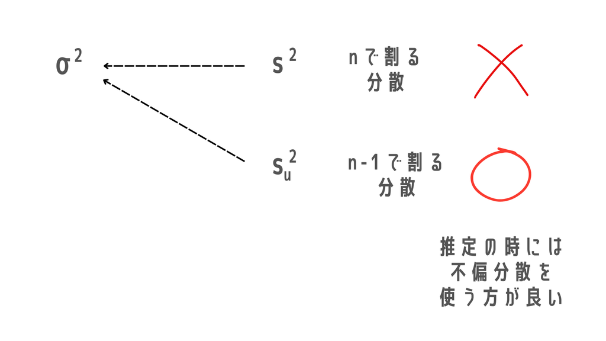

数学的な証明をするのも面白いですが，ここでは`Python`を使った**シミュレーション**を紹介しましょう．繰り返し処理を行う`for`文を使って，何度も標本抽出を繰り返し，その標本について２種類の分散を計算してみます．

```python
import numpy as np

#nで割る分散を入れるリストを作る
variances = []
#n-1で割る分散を入れるリストを作る
ub_variances = []

#平均50, 分散100の正規母集団からn=5のサンプルを抽出して，
#２種類の分散を計算することを100000回繰り返す．
for i in range(100000):
    sample = np.random.normal(loc=50, scale=10, size=5)
    var = np.var(sample)
    ubvar = np.var(sample, ddof=1)
    variances.append(var)
    ub_variances.append(ubvar)

#nで割る分散の平均
np.mean(variances)
```

```
79.90683663539534
```

```python
#n-1で割る分散の平均
np.mean(ub_variances)
```

```
99.88354579424417
```

するとどうでしょう．不偏分散の平均値の方が，真の分散100に近いのがわかりますか？

**問題２**

上記の`Python`スクリプトの繰り返し処理の回数や，サンプルサイズを変更してみると，どのようなことがいえるだろうか．

**解答２**

`range(???)`：繰り返し処理の回数を減らすと，最後の値が安定しなくなる．  
`size=???`：サンプルサイズを大きくすると２つの分散の差は小さくなっていく．

## 4. 変動係数

次に**変動係数（Coefficients of Variation：CV）**について学びましょう．変動係数は以下のように定義されます．

**変動係数（Coefficients of Variation：CV）**

ある量的変数の平均値$\bar{x}$と標準偏差が$s$のとき，**変動係数（Coefficients of Variation）$CV$**を

$$CV = \frac{s}{\bar{x}}$$
と定義する．

変動係数は，**変数のスケールに対する相対的なばらつき**は表す指標であると説明されます．これを考えてみましょう．

例えば，`身長`という変数があり，平均が165，標準偏差が10だったとしましょう．次に`足の大きさ`という変数があり，平均が26，標準偏差が3だったとします．

絶対的なばらつき（=標準偏差）は，`足の大きさ`よりも`身長`の方が大きいのですが，この場合の標準偏差の比較（10 > 3）は何か不公平な気がしませんか？これは，元々の変数のスケールが身長と足の大きさでは違うということに起因した尤もっともな感覚です．

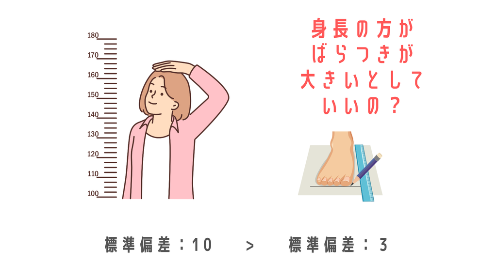

そこで，平均値との比をとることで，**スケールフリーなばらつき**を表現しようというのが，変動係数の目的です．

それぞれ計算をしてみると，

$$CV_{身長} = \frac{10}{165} \approx 0.06$$
$$CV_{足} = \frac{3}{26} \approx 0.12$$
となって，足の大きさの方が（平均値との相対的な）ばらつきが大きいと判断することができます．

## 5. 標準化と偏差値

**偏差値（deviation value）**という言葉は聞いたことがあるでしょう．日本では，ほぼあらゆるテストに偏差値という評価基準が用いられています．

しかし，この偏差値とは何なのかきちんと説明できる人は少ないのではないでしょうか？

なんとなく**「平均点が低いテストで良い点を取ると偏差値は高い．」**というイメージはあるかもしれませんね．しかしながら，「平均値が同じ２つのテストで，同じ点数を取っても同じ偏差値にならなかった．」そんな経験ありませんか？

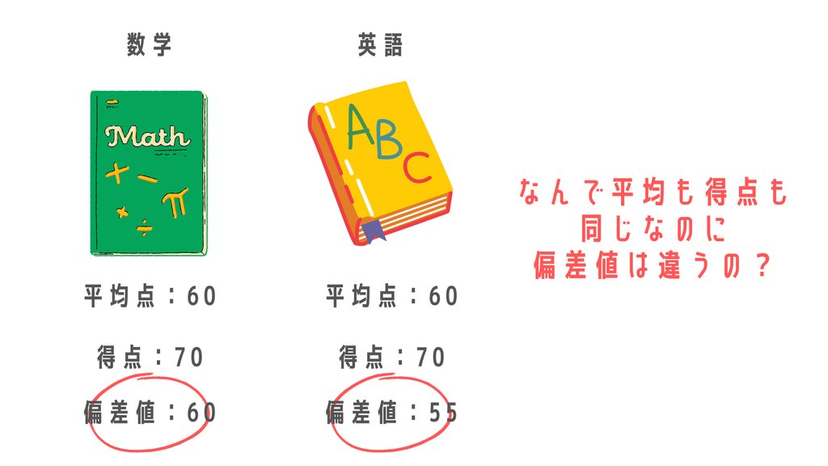

この節では，偏差値の正体について解説をします．ただし，統計的には偏差値を求める前に行う**標準化（standardize）**という操作の方が重要です．標準化と偏差値について先に定義しておくと以下のようになります．

**標準化（standardize）/ 偏差値（deviation score）**

ある量的変数$X$について，$x_1, x_2, \cdots, x_n$の観測値が得られており，その平均値は$\bar{x}$，標準偏差は$s$であるとする．

このとき，$i$番目のデータの標準化得点$z_i$は，

$$z_i = \frac{x_i - \bar{x}}{s}$$
と定義される．また$z_i$を用いて，$i$番目のデータの偏差値$t_i$は．

$$t_i = 10z_i + 50$$
と定義する．

標準化について解説するために，以下のような問題について考えてみます．

**問題３**

２つの数学のテストA, B（100点満点）がある． それぞれ何人かの受験者がいて，テストAの平均点は50点，標準偏差は20であり， テストBの平均点は30点で，標準偏差は18である．

この２つのテストで，作道くんはテストAで80点，池田くんはテストBで57点をとった．このとき，作道くんと池田くんはどちらが優秀といえるか．

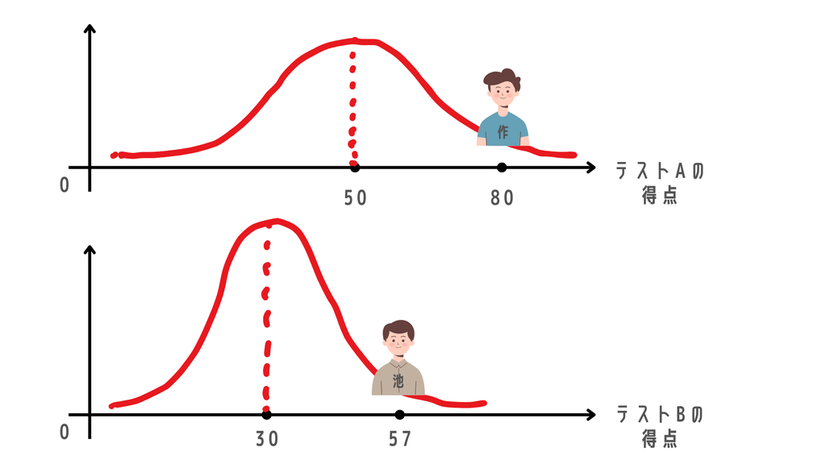

**解答３**

素点で比べると，作道くん80点，池田くん57点だから，作道くんの方が優秀と言えそう，しかし素点での比較は試験の難易度や得点のばらつきが考慮されていない．

ここで２人の標準化得点$z_i = \frac{x_i - \bar{x}}{s}$を求める．ここで標準化得点の意味は，**偏差が標準偏差の何倍になっているか**である．

$$z_{作道} = \frac{80-50}{20} = 1.5$$
$$z_{池田} = \frac{57 - 30}{18} = 1.5$$
すなわち２人の標準化得点は同じであり，偏差値$t_i = 10z_i + 50$についても，
$$t_{作道} = 10 \cdot 1.5 + 50 = 65$$
$$t_{池田} = 10 \cdot 1.5 + 50 = 65$$

となる．

**問題４**

上の議論から，２人の学力が等しいと結論するにはいくつかの前提が必要である．その前提について考えてみなさい．

**解答４**

受験者集団の学力，得点分布の形状など

## 6. 演習

最後に問題を解くことで，今回の理解を深めておきましょう．計算方法は手計算でも，電卓でも，`Python`を使ってもなんでもいいです．

**問題５**

以下のような，銘柄A，Bの株価データがある．

| 日時 | 5/7 | 5/8 | 5/9 | 5/10 | 5/11 | 5/14 | 5/15 | 5/16 |
| --- | --- | --- | --- | --- | --- | --- | --- | --- |
| A | 100 | 120 | 140 | 135 | 145 | 135 | 125 | 130 |
| B | 1200 | 1210 | 1220 | 1240 | 1320 | 1310 | 1300 | 1260 |

**問5-1** 銘柄AとBの標準偏差（nで割って良い）を求めよ．  
**問5-2** 銘柄AとBの変動係数を求めよ．  
**問5-3** このことから銘柄A, Bのリスクについて考察してみなさい．

**解答５**

以下`Python`でのコードを示す．

```python
import numpy as numpy

#データの作成
A = np.array([100,120,140,135,145,135,125,130])
B = np.array([1200,1210,1220,1240,1320,1310,1300,1260])
```

**問5-1**

```python
#標準偏差の計算（np.stdを使ってもいいよ）
s_A = np.sqrt(sum((A - np.mean(A))**2)/len(A))
s_B = np.sqrt(sum((B - np.mean(B))**2)/len(B))
print('Aの標準偏差は', s_A,'Bの標準偏差は',s_B)
```

```
Aの標準偏差は 13.169567191065923 Bの標準偏差は 44.37059837324712
```

**問5-2**

```python
CV_A = s_A/np.mean(A)
CV_B = s_B/np.mean(B)
print('Aの変動係数は', CV_A,'Bの変動係数は',CV_B)
```

```
Aの変動係数は 0.10228790051313338 Bの変動係数は 0.03528477007812892
```

**問5-3**

標準偏差はAの方が小さいが，変動係数を計算するとAの方が大きい．従ってA, Bに同額の投資（株数はAのが多くなる）を行えば，Aの方が価格変動のリスクが高いと判断できる．

**問題６**

ある数学と理科のテストの平均値と分散はそれぞれ以下のようであった．

| ＼ | 数学 | 理科 |
| --- | --- | --- |
| 平均 | 50 | 40 |
| 分散 | 400 | 100 |

瀬下くんは数学のテストが100点，理科のテストが70点だった．それぞれのテストの偏差値を求めなさい．

**解答６**

以下`Python`でのコードを示す．

```python
#数学の標準化得点
z_m = (100 - 50)/np.sqrt(400)
#理科の標準化得点
z_s = (70 - 40)/np.sqrt(100)

#数学の偏差値
t_m = 10 * z_m + 50
#理科の偏差値
t_s = 10 * z_s + 50
print('数学の偏差値は', t_m, '理科の偏差値は', t_s)
```

```
数学の偏差値は 75.0 理科の偏差値は 80.0
```